# Tugas Individu - 3

# Input Data

```r
library(readr)
library(MLmetrics)
Udara <- read_csv("C:\\Users\\bagan\\OneDrive\\Kuliah\\MPDW\\Metode-Peramalan-Deret-Waktu\\Pertemuan 3\\NewDelhi_Air_quality.csv")
head(Udara)
```

```
## # A tibble: 6 × 12
##    ...1   AQI    CO datetime     no2    o3  pm10  pm25   so2 timestamp_local
##   <dbl> <dbl> <dbl> <chr>      <dbl> <dbl> <dbl> <dbl> <dbl> <dttm>
## 1     0  30.2  199. 2022-10-… 0.0469  55.8 10.5   5.64 0.387 2022-10-21 23:00:00
## 2     1  28.2  198. 2022-10-… 0.0465  54.9 10.7   4.62 0.410 2022-10-22 00:00:00
## 3     2  26.6  199. 2022-10-… 0.0469  54.6 11.2   3.52 0.402 2022-10-22 01:00:00
## 4     3  25    202. 2022-10-… 0.0482  55.1 11.1   2.23 0.376 2022-10-22 02:00:00
## 5     4  26    205. 2022-10-… 0.0489  55.8 10.4   1.98 0.339 2022-10-22 03:00:00
## 6     5  26    209. 2022-10-… 0.0502  56.5  9.40  1.79 0.313 2022-10-22 04:00:00
## # ℹ 2 more variables: timestamp_utc <dttm>, ts <dbl>
```

# Menetapkan Variabel

```r
Y <- Udara$AQI
X <- Udara$pm25
data_model_bersih <- data.frame(Y = Y, X = X)
```

# Check Missing Value

```r
sum(is.na(data_model_bersih$Y))
```

```
## [1] 0
```

```r
sum(is.na(data_model_bersih$X))
```

```
## [1] 0
```

# Splitting Data

```r
# (80% untuk Train)
batas <- round(0.8 * nrow(data_model_bersih))

# Memecah data
data_train <- data_model_bersih[1:batas, ]
data_test <- data_model_bersih[(batas+1):nrow(data_model_bersih), ]

# Melihat jumlah data latih dan uji
cat("Jumlah Data Latih:", nrow(data_train), "\n")
```

```
## Jumlah Data Latih: 58
```

```r
cat("Jumlah Data Uji:", nrow(data_test), "\n")
```

```
## Jumlah Data Uji: 14
```

# 1. Model Koyck

## Library

```r
library(dLagM)
```

## Model Koyck

```r
model_koyck <- koyckDlm(x = data_train$X, y = data_train$Y)

summary(model_koyck)
```

```
##
## Call:
## "Y ~ (Intercept) + Y.1 + X.t"
##
## Residuals:
##      Min       1Q   Median       3Q      Max
## -2.14443 -0.61319  0.03512  0.48195  2.18725
##
## Coefficients:
##             Estimate Std. Error t value Pr(>|t|)
## (Intercept)   4.0771     1.8299   2.228   0.0301 *
## Y.1           0.8897     0.0588  15.131   <2e-16 ***
## X.t          -0.5723     0.2854  -2.005   0.0500 *
## ---
## Signif. codes:  0 '***' 0.001 '**' 0.01 '*' 0.05 '.' 0.1 ' ' 1
##
## Residual standard error: 0.9279 on 54 degrees of freedom
## Multiple R-Squared: 0.8273,  Adjusted R-squared: 0.8209
## Wald test: 129.1 on 2 and 54 DF,  p-value: < 2.2e-16
##
## Diagnostic tests:
## NULL
##
##                             alpha       beta       phi
## Geometric coefficients:  36.94716 -0.5722988 0.8896496
```

**Interpretasi**:Jika P-value dari peubah $Y_{t-1}$ dan $X_t < 0.05$, maka kedua peubah tersebut berpengaruh signifikan terhadap $Y_t$. Peubah $Y_{t-1}$ memiliki koefisien sebesar 0.8897, sehingga peningkatan $Y_{t-1}$ sebesar satu satuan akan meningkatkan $Y_t$ sebesar 0.8897 satuan, dengan asumsi $X_t$ konstan. Sementara itu, $X_t$ memiliki koefisien sebesar -0.5723, sehingga peningkatan $X_t$ sebesar satu satuan akan menurunkan $Y_t$ sebesar 0.5723 satuan, dengan asumsi $Y_{t-1}$ konstan. Koefisien $Y_{t-1}$ sebesar 0.8897 menunjukkan tingkat persistensi/pengaruh nilai masa lalu terhadap nilai saat ini.

Persamaan:
$$\hat{Y}_t = 4.0771 - 0.5723X_t + 0.8897Y_{t-1}$$
## Peramalan

```r
# Meramalkan 5 periode ke depan
fore.koyck <- forecast(model = model_koyck, x = data_test$X, h = nrow(data_test))
fore.koyck
```

```
## $forecasts
##  [1] 22.96490 22.79987 22.60639 22.40415 22.24036 22.15991 22.16242 22.20757
##  [9] 22.27123 22.33380 22.39368 22.42982 22.44082 22.47014
##
## $call
## forecast.koyckDlm(model = model_koyck, x = data_test$X, h = nrow(data_test))
##
## attr(,"class")
## [1] "forecast.koyckDlm" "dLagM"
```

```r
# Cek Akurasi (MAPE) pada data testing
mape_koyck <- MLmetrics::MAPE(data_test$Y, fore.koyck$forecasts)

cat("MAPE Model Koyck:", mape_koyck, "\n")
```

```
## MAPE Model Koyck: 0.1064556
```

# 2. Model Distribusi Lag

## Pemodelan (Lag = 2)

```r
model.dlm <- dlm(
  x = data_train$X,
  y = data_train$Y,
  q = 2
)

summary(model.dlm)
```

```
##
## Call:
## lm(formula = model.formula, data = design)
##
## Residuals:
##     Min      1Q  Median      3Q     Max
## -4.5504 -1.2693 -0.0678  1.0780  4.0378
##
## Coefficients:
##             Estimate Std. Error t value Pr(>|t|)
## (Intercept)   35.453      1.656  21.405  < 2e-16 ***
## x.t           -8.438      2.173  -3.883 0.000293 ***
## x.1            6.515      3.189   2.043 0.046126 *
## x.2           -2.178      1.553  -1.403 0.166651
## ---
## Signif. codes:  0 '***' 0.001 '**' 0.01 '*' 0.05 '.' 0.1 ' ' 1
##
## Residual standard error: 1.84 on 52 degrees of freedom
## Multiple R-squared:  0.343,  Adjusted R-squared:  0.3051
## F-statistic: 9.048 on 3 and 52 DF,  p-value: 6.393e-05
##
## AIC and BIC values for the model:
##        AIC      BIC
## 1 233.0605 243.1873
```

## Penentuan Lag Optimum

```r
# tempat untuk menyimpan nilai AIC
aic_dlm <- numeric(10)

# cari nilai AIC untuk lag 1 sampai 10
for (i in 1:10) {
  model_sementara <- dlm(
    x = data_train$X,
    y = data_train$Y,
    q = i
  )

  aic_dlm[i] <- AIC(model_sementara$model)
}

# Menampilkan AIC setiap lag
aic_dlm
```

```
##  [1] 246.7199 233.0605 220.3167 209.9314 204.0812 201.1051 200.0655 199.1205
##  [9] 195.5979 186.2653
```

## Penentuan Lag dari AIC terkecil

```r
# Menentukan lag dengan AIC terkecil
lag_opt_dlm <- which.min(aic_dlm)

print(
  paste(
    "Lag optimum untuk model DLM adalah:",
    lag_opt_dlm
  )
)
```

```
## [1] "Lag optimum untuk model DLM adalah: 10"
```

## Pemodelan

```r
model_dlm_final <- dlm(
  x = data_train$X,
  y = data_train$Y,
  q = lag_opt_dlm
)

summary(model_dlm_final)
```

```
##
## Call:
## lm(formula = model.formula, data = design)
##
## Residuals:
##     Min      1Q  Median      3Q     Max
## -2.8038 -0.8916 -0.1139  0.8262  2.9915
##
## Coefficients:
##             Estimate Std. Error t value Pr(>|t|)
## (Intercept)   39.894      2.184  18.264  < 2e-16 ***
## x.t          -15.772      5.197  -3.035  0.00445 **
## x.1            7.398     12.991   0.569  0.57259
## x.2            6.854     16.729   0.410  0.68445
## x.3           -2.024     16.055  -0.126  0.90037
## x.4            1.510     15.044   0.100  0.92063
## x.5          -10.589     14.301  -0.740  0.46381
## x.6           19.702     12.033   1.637  0.11028
## x.7          -16.886      6.743  -2.504  0.01693 *
## x.8            1.674      4.389   0.381  0.70509
## x.9            6.618      4.381   1.511  0.13962
## x.10          -4.613      2.042  -2.259  0.03004 *
## ---
## Signif. codes:  0 '***' 0.001 '**' 0.01 '*' 0.05 '.' 0.1 ' ' 1
##
## Residual standard error: 1.483 on 36 degrees of freedom
## Multiple R-squared:  0.6391, Adjusted R-squared:  0.5288
## F-statistic: 5.795 on 11 and 36 DF,  p-value: 2.646e-05
##
## AIC and BIC values for the model:
##        AIC      BIC
## 1 186.2653 210.5909
```

**Interpretasi**:Berdasarkan hasil pemodelan DLM dengan lag optimum $q=10$, diperoleh nilai $R^2=0,6391$, yang berarti model mampu menjelaskan 63,91% variasi Y. Secara simultan, model signifikan dengan p-value uji F sebesar 2,646 × 10⁻⁵ < 0,05.

Secara parsial, $X_t$, $X_{t-7}$, dan $X_{t-10}$ berpengaruh signifikan terhadap $Y_t$, dengan masing-masing koefisien -15,772, -16,886, dan -4,613. Sementara itu, lag lainnya tidak berpengaruh signifikan pada taraf 5%. Model memiliki AIC sebesar 186,2653.

## Peramalan

```r
# Peramalan model DLM
fore.dlm <- forecast(
  model = model_dlm_final,
  x = data_test$X,
  h = nrow(data_test)
)

fore.dlm
```

```
## $forecasts
##  [1] 19.45431 20.79466 22.01949 21.85673 22.86199 25.71254 24.95044 25.21888
##  [9] 23.33608 23.52337 23.53436 22.05540 21.69674 23.23584
##
## $call
## forecast.dlm(model = model_dlm_final, x = data_test$X, h = nrow(data_test))
##
## attr(,"class")
## [1] "forecast.dlm" "dLagM"
```

```r
# Menghitung MAPE
mape.dlm <- MLmetrics::MAPE(
  fore.dlm$forecasts,
  data_test$Y
)

cat("MAPE Model DLM:", mape.dlm, "\n")
```

```
## MAPE Model DLM: 0.140921
```

# 3. Model Autoregressive Distributed Lag (ARDL)

## Pemodelan

```r
# Model ARDL dengan lag X = 1 dan lag Y = 1
model.ardl <- ardlDlm(
  formula = Y ~ X,
  data = data_train,
  p = 1,
  q = 1
)

summary(model.ardl)
```

```
##
## Time series regression with "ts" data:
## Start = 2, End = 58
##
## Call:
## dynlm(formula = as.formula(model.text), data = data)
##
## Residuals:
##      Min       1Q   Median       3Q      Max
## -2.14374 -0.61593  0.03152  0.47781  2.18777
##
## Coefficients:
##             Estimate Std. Error t value Pr(>|t|)
## (Intercept)  4.00535    2.07382   1.931   0.0588 .
## X.t         -0.52588    0.80265  -0.655   0.5152
## X.1         -0.03046    0.55965  -0.054   0.9568
## Y.1          0.89112    0.06338  14.060   <2e-16 ***
## ---
## Signif. codes:  0 '***' 0.001 '**' 0.01 '*' 0.05 '.' 0.1 ' ' 1
##
## Residual standard error: 0.9366 on 53 degrees of freedom
## Multiple R-squared:  0.8273, Adjusted R-squared:  0.8175
## F-statistic: 84.63 on 3 and 53 DF,  p-value: < 2.2e-16
```

**Interpretasi**:Berdasarkan hasil pemodelan ARDL dengan $p=1$ dan $q=1$, diperoleh nilai $R^2=0,8273$, yang berarti model mampu menjelaskan 82,73% variasi Y. Variabel $Y_{t-1}$ berpengaruh positif dan signifikan terhadap $Y_t$ dengan koefisien 0,89112 dan p-value < 0,05. Sementara itu, $X_t$ dan $X_{t-1}$ tidak berpengaruh signifikan terhadap $Y_t$ karena memiliki p-value > 0,05.

## Lag Optimum ARDL

```r
# Mencari kombinasi lag optimum ARDL
model.ardl.opt <- ardlBoundOrders(
  data = data.frame(data_train),
  ic = "AIC",
  formula = Y ~ X
)

# Menentukan kombinasi lag dengan AIC terkecil
min_p <- c()

for (i in 1:6) {
  min_p[i] <- min(model.ardl.opt$Stat.table[[i]])
}

q_opt <- which(
  min_p == min(min_p, na.rm = TRUE)
)

p_opt <- which(
  model.ardl.opt$Stat.table[[q_opt]] ==
    min(model.ardl.opt$Stat.table[[q_opt]], na.rm = TRUE)
)

data.frame(
  "Lag_Y_opt(q)" = q_opt,
  "Lag_X_opt(p)" = p_opt,
  "AIC" = model.ardl.opt$min.Stat
)
```

```
##   Lag_Y_opt.q. Lag_X_opt.p.      AIC
## 1            5           10 61.97934
```

## Pemodelan dengan Lag Optimum

```r
# Membentuk model ARDL dengan lag optimum
model_ardl_final <- ardlDlm(
  formula = Y ~ X,
  data = data_train,
  p = p_opt,
  q = q_opt
)

summary(model_ardl_final)
```

```
##
## Time series regression with "ts" data:
## Start = 11, End = 58
##
## Call:
## dynlm(formula = as.formula(model.text), data = data)
##
## Residuals:
##      Min       1Q   Median       3Q      Max
## -0.86582 -0.31189 -0.07375  0.34912  1.19081
##
## Coefficients:
##             Estimate Std. Error t value Pr(>|t|)
## (Intercept)  12.6244     2.9250   4.316 0.000151 ***
## X.t          -7.0126     2.1911  -3.200 0.003161 **
## X.1           7.0163     5.0141   1.399 0.171648
## X.2           1.5115     6.4740   0.233 0.816929
## X.3           1.2333     6.2628   0.197 0.845169
## X.4          -5.5580     5.8864  -0.944 0.352366
## X.5           2.3320     5.8275   0.400 0.691767
## X.6           2.2332     5.1837   0.431 0.669592
## X.7          -6.3338     3.0574  -2.072 0.046711 *
## X.8           2.0126     1.7550   1.147 0.260266
## X.9           2.5398     1.8294   1.388 0.174936
## X.10         -2.0485     0.8651  -2.368 0.024310 *
## Y.1           0.6735     0.1655   4.069 0.000302 ***
## Y.2           0.3316     0.2088   1.588 0.122375
## Y.3           0.1100     0.2014   0.546 0.588760
## Y.4          -0.1269     0.1971  -0.644 0.524558
## Y.5          -0.2970     0.1510  -1.967 0.058168 .
## ---
## Signif. codes:  0 '***' 0.001 '**' 0.01 '*' 0.05 '.' 0.1 ' ' 1
##
## Residual standard error: 0.5603 on 31 degrees of freedom
## Multiple R-squared:  0.9557, Adjusted R-squared:  0.9328
## F-statistic: 41.75 on 16 and 31 DF,  p-value: < 2.2e-16
```

**Interpretasi**:Berdasarkan hasil pemodelan ARDL dengan lag optimum, diperoleh nilai $R^2=0,9557$, yang berarti model mampu menjelaskan 95,57% variasi Y. Secara simultan, model signifikan dengan p-value uji F < 2,2 × 10⁻¹⁶ < 0,05.

Secara parsial, $X_t$, $X_{t-7}$, $X_{t-10}$, dan $Y_{t-1}$ berpengaruh signifikan terhadap $Y_t$. Koefisiennya masing-masing sebesar -7,0126, -6,3338, -2,0485, dan 0,6735. Sementara itu, lag lainnya tidak berpengaruh signifikan pada taraf 5%. ## Peramalan dengan Lag Optimum

```r
# Peramalan ARDL dengan lag optimum
fore.ardl <- forecast(
  model = model_ardl_final,
  x = data_test$X,
  h = nrow(data_test)
)

fore.ardl
```

```
## $forecasts
##  [1] 21.76279 21.36728 21.69928 21.68369 23.08246 24.44344 25.26643 25.38682
##  [9] 25.05264 24.60028 23.81773 22.38917 21.44751 21.15079
##
## $call
## forecast.ardlDlm(model = model_ardl_final, x = data_test$X, h = nrow(data_test))
##
## attr(,"class")
## [1] "forecast.ardlDlm" "dLagM"
```

```r
# Menghitung MAPE
mape.ardl <- MLmetrics::MAPE(
  fore.ardl$forecasts,
  data_test$Y
)

cat("MAPE Model ARDL Optimum:", mape.ardl, "\n")
```

```
## MAPE Model ARDL Optimum: 0.1436781
```

# Evaluasi Asumsi Model

## Library

```r
library(lmtest)
library(Metrics)
library(ggplot2)
```

## Uji Asumsi Model

### Model Koyck

```r
# 1. Uji Normalitas
shapiro.test(residuals(model_koyck$model))
```

```
##
##  Shapiro-Wilk normality test
##
## data:  residuals(model_koyck$model)
## W = 0.98008, p-value = 0.467
```

```r
# 2. Uji Autokorelasi
bgtest(model_koyck$model)
```

```
##
##  Breusch-Godfrey test for serial correlation of order up to 1
##
## data:  model_koyck$model
## LM test = 13.004, df = 1, p-value = 0.0003108
```

```r
# 3. Uji Homoskedastisitas
bptest(model_koyck$model)
```

```
##
##  studentized Breusch-Pagan test
##
## data:  model_koyck$model
## BP = 0.62294, df = 2, p-value = 0.7324
```

### Model Distribusi Lag

```r
# 1. Uji Normalitas
shapiro.test(residuals(model_dlm_final$model))
```

```
##
##  Shapiro-Wilk normality test
##
## data:  residuals(model_dlm_final$model)
## W = 0.98932, p-value = 0.9373
```

```r
# 2. Uji Autokorelasi
bgtest(model_dlm_final$model)
```

```
##
##  Breusch-Godfrey test for serial correlation of order up to 1
##
## data:  model_dlm_final$model
## LM test = 32.292, df = 1, p-value = 1.327e-08
```

```r
# 3. Uji Homoskedastisitas
bptest(model_dlm_final$model)
```

```
##
##  studentized Breusch-Pagan test
##
## data:  model_dlm_final$model
## BP = 12.022, df = 11, p-value = 0.362
```

### Model Autoregressive Distributed Lag (ARDL)

```r
# 1. Uji Normalitas
shapiro.test(residuals(model_ardl_final$model))
```

```
##
##  Shapiro-Wilk normality test
##
## data:  residuals(model_ardl_final$model)
## W = 0.97847, p-value = 0.5167
```

```r
# 2. Uji Autokorelasi
bgtest(model_ardl_final$model)
```

```
##
##  Breusch-Godfrey test for serial correlation of order up to 1
##
## data:  model_ardl_final$model
## LM test = 2.8964, df = 1, p-value = 0.08878
```

```r
# 3. Uji Homoskedastisitas
bptest(model_ardl_final$model)
```

```
##
##  studentized Breusch-Pagan test
##
## data:  model_ardl_final$model
## BP = 18.049, df = 16, p-value = 0.3211
```

# Perbandingan Performa Model

## Akurasi

```r
# Ringkasan Akurasi
akurasi <- matrix(
  c(
    mape_koyck,
    mape.dlm,
    mape.ardl
  )
)

row.names(akurasi) <- c(
  "Koyck",
  "DLM Optimum",
  "ARDL (1,1)"
)

colnames(akurasi) <- c("MAPE")

print(akurasi)
```

[output not shown]

## Visualisasi

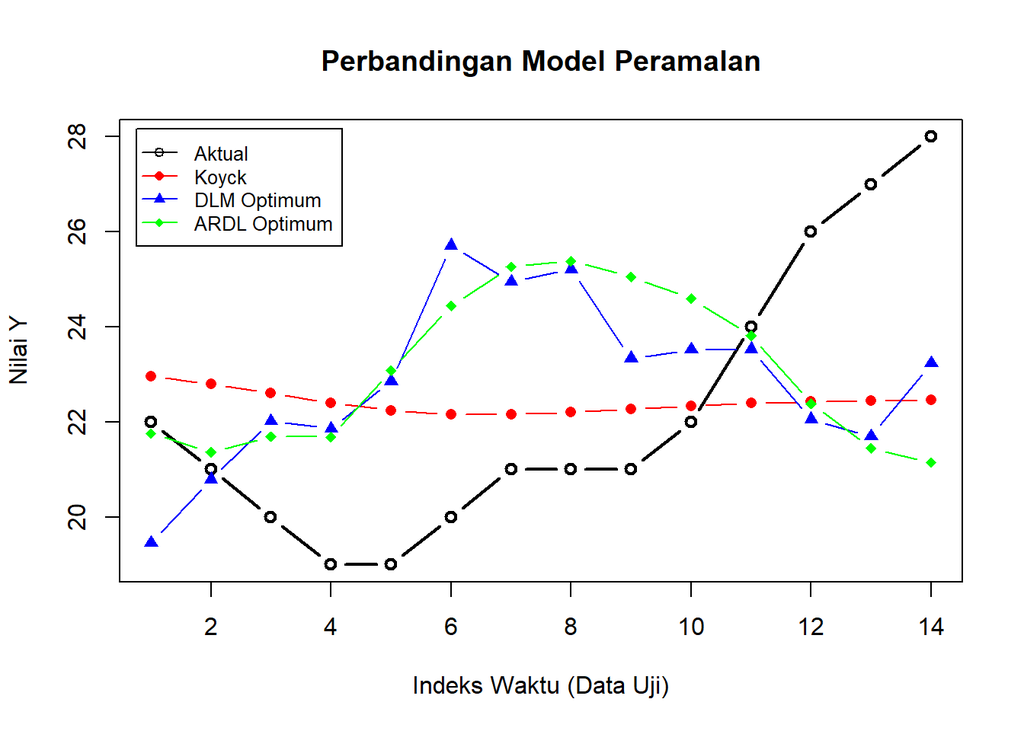

```r
par(mfrow = c(1,1))

# Sumbu X = urutan waktu data testing
waktu <- 1:nrow(data_test)

plot(
  waktu,
  data_test$Y,
  type = "b",
  col = "black",
  lwd = 2,
  pch = 1,
  ylab = "Nilai Y",
  xlab = "Indeks Waktu (Data Uji)",
  main = "Perbandingan Model Peramalan"
)

lines(
  waktu,
  fore.koyck$forecasts,
  col = "red",
  type = "b",
  pch = 16
)

lines(
  waktu,
  fore.dlm$forecasts,
  col = "blue",
  type = "b",
  pch = 17
)

lines(
  waktu,
  fore.ardl$forecasts,
  col = "green",
  type = "b",
  pch = 18
)

legend(
  "topleft",
  legend = c(
    "Aktual",
    "Koyck",
    "DLM Optimum",
    "ARDL Optimum"
  ),
  col = c("black", "red", "blue", "green"),
  lty = 1,
  pch = c(1, 16, 17, 18),
  cex = 0.8,
  inset = 0.02
)
```